# Assignment3

Wei Zheng

9/24/2019

## 乐高数据可视化

### 案例背景

乐高公司于1932年在丹麦创立，至今已有87年的发展历史。其发行的玩具套装构思惊奇、设计巧妙，受到世界各地各个年龄人们的喜爱，可谓是世界上最受欢迎的玩具之一。制作精美的玩具自然在各个环节都精雕细琢——从各个零件的设计及其颜色，再到零件间的搭配从而形成套装，甚至套装亦能互相结合形成新的、更大的套装；而同时，与时俱进的推出新的主题，也是乐高玩具经久不衰的重要原因之一。在本案例当中，我们将从零件到套装、再到主题，对乐高近70年出品的玩具进行分析，一睹乐高玩具世界的炫彩缤纷。

### 数据介绍

本案例所用数据来源于乐高官方网站，包含主题、套装、零件等8个数据集，数据集之间通过变量相互连接。更详细数据介绍见本案例推文：https://mp.weixin.qq.com/s/gc7uy68Gl95GXJHOTTD1VQ

### 学习目标

- ggplot2绘图
- 锻炼处理存在复杂关联的数据集的能力
- 使用tidyverse管道式写法进行数据处理

### 准备工作

加载所用R包

### 任务一：数据读入

1. 读入各个csv文件，并按照文件名进行命名
2. 去掉1949年以前和2019年的数据

### 任务二：数据处理之颜色变量

1. 计算color表中出现过的颜色的数量，将其命名为num_colors
2. 将colors当中的rgb指标在开头增加‘#’，便于稍后绘图时，直接使用rgb录入配色
3. 将颜色的rgb数据单独保存，命名为my_color

```
## [1] "number of color:"
```

```
## [1] 178
```

```
## [1] "head of my_color"
```

```
##   #0033B2   #05131D   #0055BF
## "#0033B2" "#05131D" "#0055BF"
```

### 任务三：数据处理

注：本任务主要针对数据集相互关联、生成新数据集，为使用ggplot2绘图准备数据

1. 计算每年套装平均零件数,命名为part_year,包含year、avg_parts两个变量
2. 将part_category、parts、colors、themes、sets数据集当中的name变量分别命名为part_category_name、part_name、color_name、theme_name、set_name,便于以后区分
3. 将零件种类数据集和零件数据集左连接,连接所用变量为part_cat_id，新数据集命名为part_cat
4. 将part_cat数据集和零件颜色数据集和零件清单数据集左连接，分别使用变量part_num和id，新数据集命名为part_color
5. 计算各颜色在零件当中出现的次数，并按降序排列，同时颜色名称和其rgb一一对应。结果保留在命名为part_color的数据集当中，变量分别命名为color_name、rbg、part_per_color
6. 将套装和主题做连接,所用变量为theme_id,新的数据集命名为set_themes
7. 计算不同主题下套装的个数,将新的数据集命名为themes_per_set
8. 将颜色和套装进行连接
9. 提取不同颜色的出现年份、使用年数、rgb,储存为scolor

```
## [1] "head of part_year"
```

```
## # A tibble: 3 x 2
##    year avg_parts
##   <int>     <dbl>
## 1  1949      99.6
## 2  1950       1
## 3  1953      13.5
```

```
## [1] "head of part_cat"
```

```
##   id part_category_name part_num
## 1  1         Baseplates     0901
## 2  1         Baseplates     0902
## 3  1         Baseplates     0903
##                                                part_name
## 1      Baseplate 16 x 30 with Set 080 Yellow House Print
## 2 Baseplate 16 x 24 with Set 080 Small White House Print
## 3         Baseplate 16 x 24 with Set 080 Red House Print
```

```
## [1] "head of part_color"
```

```
##   id part_category_name part_num
## 1  1         Baseplates     0901
## 2  1         Baseplates     0901
## 3  1         Baseplates     0902
##                                                part_name inventory_id
## 1      Baseplate 16 x 30 with Set 080 Yellow House Print         1973
## 2      Baseplate 16 x 30 with Set 080 Yellow House Print        24756
## 3 Baseplate 16 x 24 with Set 080 Small White House Print         1973
##   color_id quantity is_spare color_name     rgb is_trans
## 1        2        1        f      Green #237841        f
## 2        2        1        f      Green #237841        f
## 3        2        1        f      Green #237841        f
```

```
## [1] "head of partsp_col"
```

```
## # A tibble: 3 x 3
## # Groups:   color_name [3]
##   color_name rgb     part_per_color
##   <fct>      <chr>            <int>
## 1 White      #FFFFFF           5629
## 2 Black      #05131D           5248
## 3 Yellow     #F2CD37           3743
```

```
## [1] "head of set_themes"
```

```
##   id theme_name set_num                       set_name year num_parts
## 1  1    Technic   001-1                          Gears 1965        43
## 2  1    Technic   002-1 4.5V Samsonite Gears Motor Set 1965         3
## 3  1    Technic  1030-1 TECHNIC I: Simple Machines Set 1985       191
```

```
## [1] "head of themes_per_set"
```

```
## # A tibble: 3 x 2
##   theme_name   set_cnt
##   <fct>          <int>
## 1 Supplemental     532
## 2 Basic Set        517
## 3 Technic          426
```

```
## [1] "head of set_color"
```

```
##   set_num        set_name year theme_id num_parts   id version part_num
## 1    00-1 Weetabix Castle 1970      414       471 5574       1    29c01
## 2    00-1 Weetabix Castle 1970      414       471 5574       1    29c01
## 3    00-1 Weetabix Castle 1970      414       471 5574       1    3001a
##   color_id quantity is_spare color_name     rgb is_trans
## 1        4        8        f        Red #C91A09        f
## 2       15        6        f      White #FFFFFF        f
## 3        1        4        f       Blue #0055BF        f
```

```
## [1] "head of scolor"
```

```
##   color_name     rgb year ys
## 1        Red #C91A09 1970 49
## 2      White #FFFFFF 1970 49
## 3       Blue #0055BF 1970 49
```

### 任务四：绘制主题箱线图

- 使用sets表中的信息，选取某一个theme_id，对其year与num_parts两列作出箱线图，对数据较少的年份进行过滤或合并展示，并给出解读

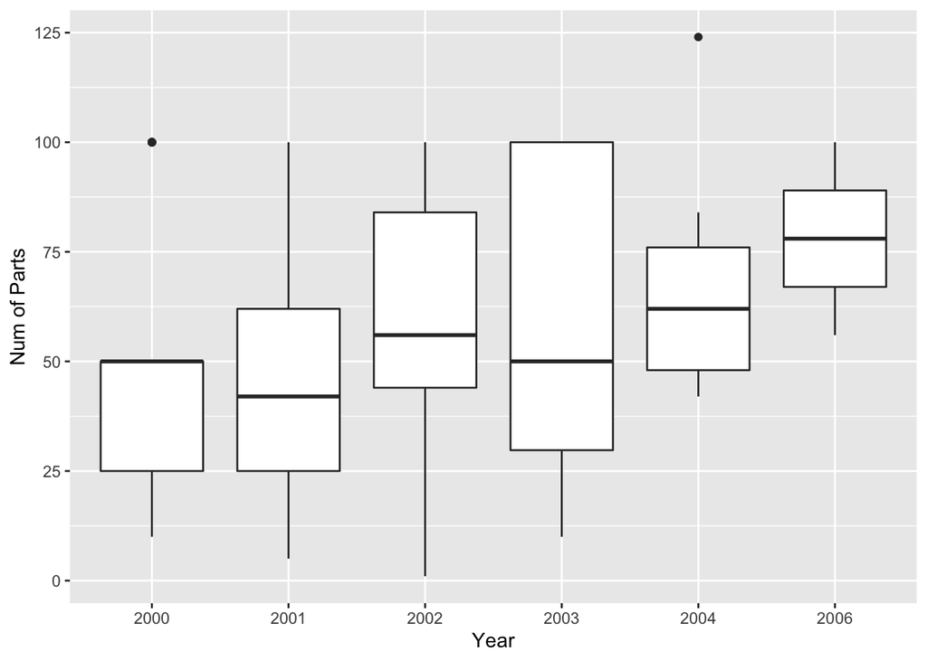

### 任务五：绘制主题数量时间序列图

- 使用sets表中的信息，绘制乐高主题数量时间序列图,并给出解读

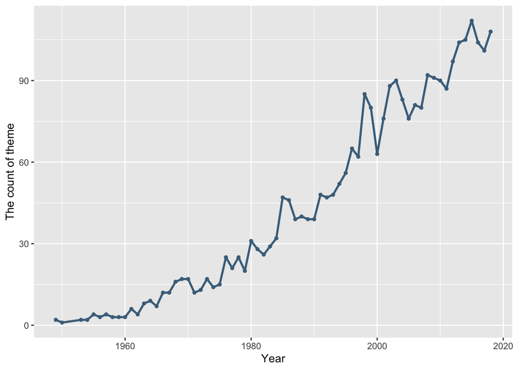

## 任务六:绘制零件类别所包含零件数量柱状图

- 使用part_cat表中信息，绘制零件类别所包含零件数量柱状图,并给出解读

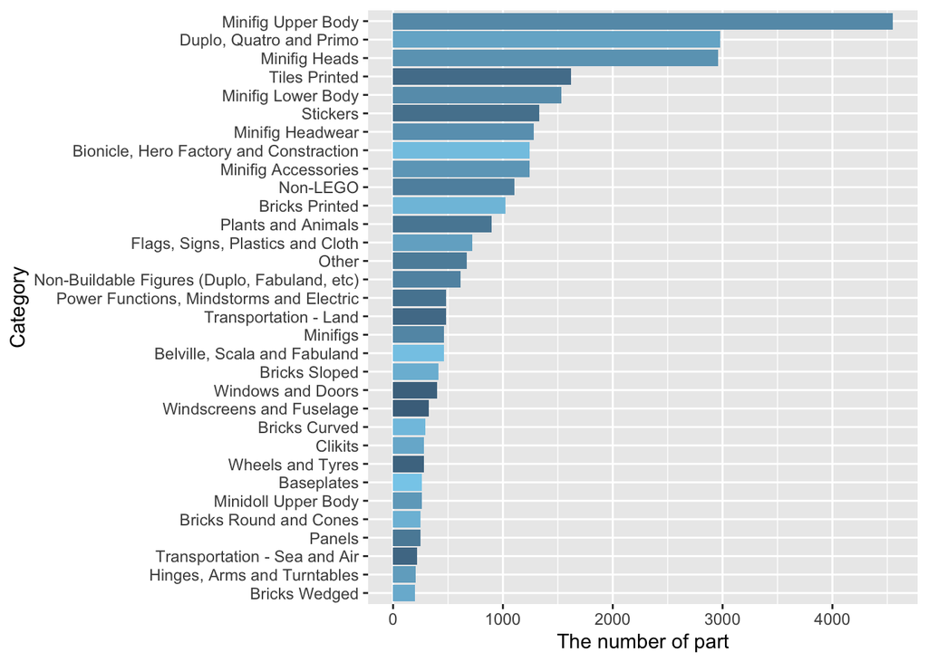

## 任务七：绘制颜色出现次数柱状图、历年颜色出现次数堆积图

- 使用partsp_col表中数据绘制颜色出现次数柱状图、使用set_color绘制历年颜色出现次数堆积图,并给出解读

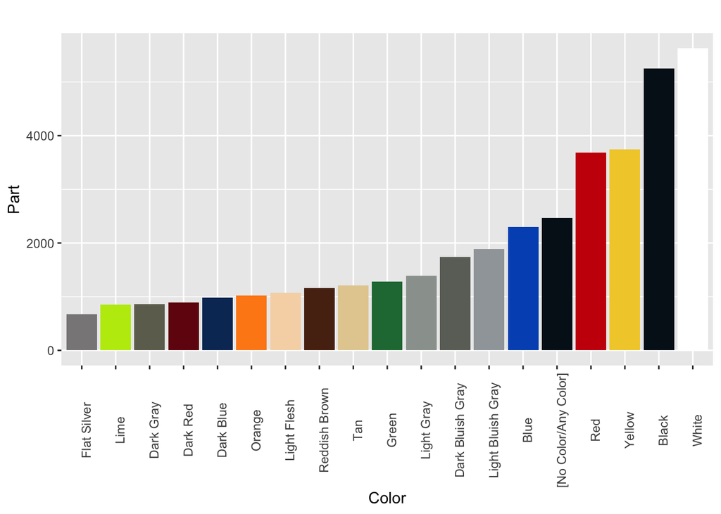

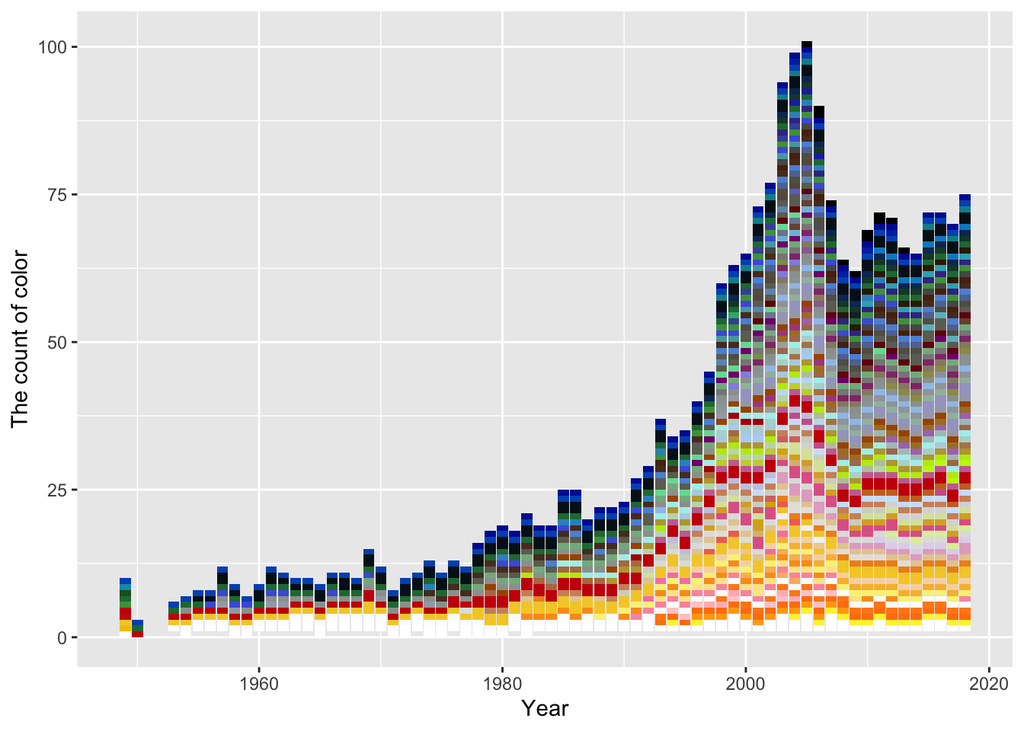